Chapter 1: Data exploration and preprocessing

1.1) DATA EXPLORATION

Read the two datasets

```r
rm(list = ls())

library(readr)
data <- read_tsv("~/Documents/R/Group\ project/metadata.tsv")
library(readr)
bact <- read_tsv("~/Documents/R/Group\ project/genera.counts.tsv")
```

Install ggplot2 and tidyverse

```r
library(ggplot2)
library(dplyr)
```

First exploration of the data: with ‘head()’ the first couple of rows are visible, with ‘dim()’ the number of rows and columns are shown and ‘colnames()’ shows the names of the columns. ‘Summary()’ gives a summary of the dataset. The summary and colnames of bact were removed after checking, to improve the readability and running time of the markdown file.

```r
head(bact)
```

```
## # A tibble: 6 × 9,695
##   Sample   d__Bacteria;p__Bacter…¹ d__Bacteria;p__Firmi…² d__Bacteria;p__Firmi…³
##   <chr>                      <dbl>                  <dbl>                  <dbl>
## 1 MSM5LLDS                       0                     25                      0
## 2 ESM5MEBE                       0                     25                     21
## 3 MSM6J2IQ                       0                     93                     58
## 4 HSM5MD62                       0                     44                     18
## 5 HSM5MD5D                       0                     51                    539
## 6 ESM5MEDN                       0                      0                     92
## # ℹ abbreviated names:
## #   ¹`d__Bacteria;p__Bacteroidota;c__Bacteroidia;o__Flavobacteriales;f__Vicingaceae;g__BCD18`,
## #   ²`d__Bacteria;p__Firmicutes_A;c__Clostridia;o__Oscillospirales;f__CAG-272;g__Flemingibacterium`,
## #   ³`d__Bacteria;p__Firmicutes_A;c__Clostridia;o__Lachnospirales;f__Lachnospiraceae;g__F0428`
## # ℹ 9,691 more variables:
## #   `d__Bacteria;p__Firmicutes_A;c__Clostridia;o__Peptostreptococcales;f__Acidaminobacteraceae;g__Fusibacter_A` <dbl>,
## #   `d__Bacteria;p__Firmicutes_A;c__Clostridia;o__Lachnospirales;f__Lachnospiraceae;g__Lachnoanaerobaculum` <dbl>, …
```

```r
head(data)
```

```
## # A tibble: 6 × 24
##   Dataset   Sample Subject Study.Group Gender DOI   Publication.Name consent_age
##   <chr>     <chr>  <chr>   <chr>       <chr>  <chr> <chr>                  <dbl>
## 1 iHMP_IBD… CSM5M… C3002   CD          Female 10.1… Multi-omics of …          76
## 2 iHMP_IBD… CSM5M… C3009   CD          Male   10.1… Multi-omics of …          56
## 3 iHMP_IBD… CSM5M… C3006   UC          Male   10.1… Multi-omics of …          32
## 4 iHMP_IBD… CSM5M… C3004   UC          Female 10.1… Multi-omics of …          47
## 5 iHMP_IBD… CSM5M… C3005   UC          Female 10.1… Multi-omics of …          76
## 6 iHMP_IBD… CSM5M… C3008   CD          Female 10.1… Multi-omics of …          53
## # ℹ 16 more variables: Age.Units <chr>, site_sub_coll <chr>,
## #   ProjectSpecificID <dbl>, week_num <dbl>, date_of_receipt <date>,
## #   interval_days <dbl>, visit_num <dbl>, site_name <chr>,
## #   `Age at diagnosis` <dbl>, Antibiotics <chr>, race <chr>, fecalcal <dbl>,
## #   BMI_at_baseline <dbl>, Height_at_baseline <dbl>, Weight_at_baseline <dbl>,
## #   `smoking status` <chr>
```

```r
dim(bact)
```

```
## [1]  382 9695
```

```r
dim(data)
```

```
## [1] 382  24
```

```r
colnames(data)
```

```
##  [1] "Dataset"            "Sample"             "Subject"
##  [4] "Study.Group"        "Gender"             "DOI"
##  [7] "Publication.Name"   "consent_age"        "Age.Units"
## [10] "site_sub_coll"      "ProjectSpecificID"  "week_num"
## [13] "date_of_receipt"    "interval_days"      "visit_num"
## [16] "site_name"          "Age at diagnosis"   "Antibiotics"
## [19] "race"               "fecalcal"           "BMI_at_baseline"
## [22] "Height_at_baseline" "Weight_at_baseline" "smoking status"
```

```r
summary(data)
```

```
##    Dataset             Sample            Subject          Study.Group
##  Length:382         Length:382         Length:382         Length:382
##  Class :character   Class :character   Class :character   Class :character
##  Mode  :character   Mode  :character   Mode  :character   Mode  :character
##
##
##
##
##     Gender              DOI            Publication.Name    consent_age
##  Length:382         Length:382         Length:382         Min.   : 6.00
##  Class :character   Class :character   Class :character   1st Qu.:14.00
##  Mode  :character   Mode  :character   Mode  :character   Median :21.00
##                                                           Mean   :27.82
##                                                           3rd Qu.:40.00
##                                                           Max.   :76.00
##                                                           NA's   :4
##   Age.Units         site_sub_coll      ProjectSpecificID    week_num
##  Length:382         Length:382         Min.   :2008      Min.   : 0.00
##  Class :character   Class :character   1st Qu.:2084      1st Qu.:13.00
##  Mode  :character   Mode  :character   Median :3034      Median :24.00
##                                        Mean   :3529      Mean   :23.95
##                                        3rd Qu.:4032      3rd Qu.:36.00
##                                        Max.   :6038      Max.   :57.00
##
##  date_of_receipt      interval_days     visit_num      site_name
##  Min.   :2013-12-11   Min.   : 0.00   Min.   : 4.00   Length:382
##  1st Qu.:2015-01-09   1st Qu.:13.00   1st Qu.:11.00   Class :character
##  Median :2015-06-04   Median :14.00   Median :18.00   Mode  :character
##  Mean   :2015-06-07   Mean   :15.74   Mean   :17.06
##  3rd Qu.:2015-10-07   3rd Qu.:16.00   3rd Qu.:25.00
##  Max.   :2016-08-22   Max.   :71.00   Max.   :30.00
##
##  Age at diagnosis Antibiotics            race              fecalcal
##  Min.   : 5.00    Length:382         Length:382         Min.   : 11.81
##  1st Qu.:13.00    Class :character   Class :character   1st Qu.: 15.50
##  Median :16.00    Mode  :character   Mode  :character   Median : 27.73
##  Mean   :21.43                                          Mean   :106.01
##  3rd Qu.:29.00                                          3rd Qu.:211.03
##  Max.   :74.00                                          Max.   :420.94
##  NA's   :108                                            NA's   :161
##  BMI_at_baseline Height_at_baseline Weight_at_baseline smoking status
##  Min.   :13.5    Min.   :112.0      Min.   : 17.60     Length:382
##  1st Qu.:18.9    1st Qu.:157.1      1st Qu.: 47.70     Class :character
##  Median :22.0    Median :165.0      Median : 61.00     Mode  :character
##  Mean   :23.3    Mean   :163.2      Mean   : 63.67
##  3rd Qu.:26.3    3rd Qu.:173.0      3rd Qu.: 80.50
##  Max.   :50.2    Max.   :193.0      Max.   :135.00
##  NA's   :87      NA's   :87         NA's   :87
```

It is striking that the ‘bact’ data consists of 9695 columns. The summary of bact does not provide useful information. However, the summary of the ‘data’ does. By using ‘skimr’ a more detailed summary of the dataset ‘data’ can be generated.

```r
library(skimr)
skim(data)
```

Data summary

| Name | data |
| --- | --- |
| Number of rows | 382 |
| Number of columns | 24 |
| _______________________ |  |
| Column type frequency: |  |
| character | 13 |
| Date | 1 |
| numeric | 10 |
| ________________________ |  |
| Group variables | None |

**Variable type: character**

| skim_variable | n_missing | complete_rate | min | max | empty | n_unique | whitespace |
| --- | --- | --- | --- | --- | --- | --- | --- |
| Dataset | 0 | 1.00 | 16 | 16 | 0 | 1 | 0 |
| Sample | 0 | 1.00 | 8 | 8 | 0 | 382 | 0 |
| Subject | 0 | 1.00 | 5 | 5 | 0 | 105 | 0 |
| Study.Group | 0 | 1.00 | 2 | 6 | 0 | 3 | 0 |
| Gender | 0 | 1.00 | 4 | 6 | 0 | 2 | 0 |
| DOI | 0 | 1.00 | 25 | 25 | 0 | 1 | 0 |
| Publication.Name | 0 | 1.00 | 73 | 73 | 0 | 1 | 0 |
| Age.Units | 0 | 1.00 | 5 | 5 | 0 | 1 | 0 |
| site_sub_coll | 0 | 1.00 | 7 | 8 | 0 | 382 | 0 |
| site_name | 0 | 1.00 | 3 | 14 | 0 | 5 | 0 |
| Antibiotics | 0 | 1.00 | 2 | 3 | 0 | 2 | 0 |
| race | 0 | 1.00 | 5 | 32 | 0 | 5 | 0 |
| smoking status | 215 | 0.44 | 12 | 14 | 0 | 3 | 0 |

**Variable type: Date**

| skim_variable | n_missing | complete_rate | min | max | median | n_unique |
| --- | --- | --- | --- | --- | --- | --- |
| date_of_receipt | 0 | 1 | 2013-12-11 | 2016-08-22 | 2015-06-04 | 197 |

**Variable type: numeric**

| skim_variable | n_missing | complete_rate | mean | sd | p0 | p25 | p50 | p75 | p100 | hist |
| --- | --- | --- | --- | --- | --- | --- | --- | --- | --- | --- |
| consent_age | 4 | 0.99 | 27.82 | 18.18 | 6.00 | 14.0 | 21.00 | 40.00 | 76.00 | ▇▃▂▂▁ |
| ProjectSpecificID | 0 | 1.00 | 3528.67 | 1298.55 | 2008.00 | 2084.0 | 3034.00 | 4032.00 | 6038.00 | ▇▆▇▁▃ |
| week_num | 0 | 1.00 | 23.95 | 13.88 | 0.00 | 13.0 | 24.00 | 36.00 | 57.00 | ▇▇▇▆▂ |
| interval_days | 0 | 1.00 | 15.74 | 9.13 | 0.00 | 13.0 | 14.00 | 16.00 | 71.00 | ▇▅▁▁▁ |
| visit_num | 0 | 1.00 | 17.06 | 7.65 | 4.00 | 11.0 | 18.00 | 25.00 | 30.00 | ▇▆▆▃▇ |
| Age at diagnosis | 108 | 0.72 | 21.43 | 12.77 | 5.00 | 13.0 | 16.00 | 29.00 | 74.00 | ▇▅▂▁▁ |
| fecalcal | 161 | 0.58 | 106.01 | 123.16 | 11.81 | 15.5 | 27.73 | 211.03 | 420.94 | ▇▁▁▁▁ |
| BMI_at_baseline | 87 | 0.77 | 23.30 | 7.23 | 13.50 | 18.9 | 22.00 | 26.30 | 50.20 | ▇▇▂▁▁ |
| Height_at_baseline | 87 | 0.77 | 163.18 | 14.77 | 112.00 | 157.1 | 165.00 | 173.00 | 193.00 | ▁▂▅▇▃ |
| Weight_at_baseline | 87 | 0.77 | 63.67 | 24.04 | 17.60 | 47.7 | 61.00 | 80.50 | 135.00 | ▃▇▇▁▁ |

**data types** What are the data types?

```r
str(data)
```

```
## spc_tbl_ [382 × 24] (S3: spec_tbl_df/tbl_df/tbl/data.frame)
##  $ Dataset           : chr [1:382] "iHMP_IBDMDB_2019" "iHMP_IBDMDB_2019" "iHMP_IBDMDB_2019" "iHMP_IBDMDB_2019" ...
##  $ Sample            : chr [1:382] "CSM5MCVN" "CSM5MCWE" "CSM5MCX3" "CSM5MCXL" ...
##  $ Subject           : chr [1:382] "C3002" "C3009" "C3006" "C3004" ...
##  $ Study.Group       : chr [1:382] "CD" "CD" "UC" "UC" ...
##  $ Gender            : chr [1:382] "Female" "Male" "Male" "Female" ...
##  $ DOI               : chr [1:382] "10.1038/s41586-019-1237-9" "10.1038/s41586-019-1237-9" "10.1038/s41586-019-1237-9" "10.1038/s41586-019-1237-9" ...
##  $ Publication.Name  : chr [1:382] "Multi-omics of the gut microbial ecosystem in inflammatory bowel diseases" "Multi-omics of the gut microbial ecosystem in inflammatory bowel diseases" "Multi-omics of the gut microbial ecosystem in inflammatory bowel diseases" "Multi-omics of the gut microbial …
##  $ consent_age       : num [1:382] 76 56 32 47 76 53 37 43 56 50 ...
##  $ Age.Units         : chr [1:382] "Years" "Years" "Years" "Years" ...
##  $ site_sub_coll     : chr [1:382] "C3002C9" "C3009C5" "C3006C9" "C3004C9" ...
##  $ ProjectSpecificID : num [1:382] 3002 3009 3006 3004 3005 ...
##  $ week_num          : num [1:382] 16 8 15 16 15 16 6 28 16 8 ...
##  $ date_of_receipt   : Date[1:382], format: "2014-08-19" "2014-09-03" ...
##  $ interval_days     : num [1:382] 13 15 13 15 13 14 14 13 14 13 ...
##  $ visit_num         : num [1:382] 13 8 13 13 13 13 7 20 13 8 ...
##  $ site_name         : chr [1:382] "Cedars-Sinai" "Cedars-Sinai" "Cedars-Sinai" "Cedars-Sinai" ...
##  $ Age at diagnosis  : num [1:382] 47 44 24 33 58 24 30 28 44 37 ...
##  $ Antibiotics       : chr [1:382] "No" "No" "No" "No" ...
##  $ race              : chr [1:382] "White" "White" "White" "White" ...
##  $ fecalcal          : num [1:382] 16 20.6 12.7 14.8 229 ...
##  $ BMI_at_baseline   : num [1:382] NA NA 20.1 NA 30.9 21.7 46.7 NA NA 22.4 ...
##  $ Height_at_baseline: num [1:382] NA NA 180 NA 165 165 170 NA NA 165 ...
##  $ Weight_at_baseline: num [1:382] NA NA 65 NA 84 59 135 NA NA 61 ...
##  $ smoking status    : chr [1:382] NA NA "Never smoked" NA ...
##  - attr(*, "spec")=
##   .. cols(
##   ..   Dataset = col_character(),
##   ..   Sample = col_character(),
##   ..   Subject = col_character(),
##   ..   Study.Group = col_character(),
##   ..   Gender = col_character(),
##   ..   DOI = col_character(),
##   ..   Publication.Name = col_character(),
##   ..   consent_age = col_double(),
##   ..   Age.Units = col_character(),
##   ..   site_sub_coll = col_character(),
##   ..   ProjectSpecificID = col_double(),
##   ..   week_num = col_double(),
##   ..   date_of_receipt = col_date(format = ""),
##   ..   interval_days = col_double(),
##   ..   visit_num = col_double(),
##   ..   site_name = col_character(),
##   ..   `Age at diagnosis` = col_double(),
##   ..   Antibiotics = col_character(),
##   ..   race = col_character(),
##   ..   fecalcal = col_double(),
##   ..   BMI_at_baseline = col_double(),
##   ..   Height_at_baseline = col_double(),
##   ..   Weight_at_baseline = col_double(),
##   ..   `smoking status` = col_character()
##   .. )
##  - attr(*, "problems")=<externalptr>
```

It would be better if some columns in the dataset ‘data’ changed from data type ‘character’ to ‘factor’.

```r
data <- data %>% mutate(Study.Group = factor(Study.Group))
data <- data %>% mutate(Gender = factor(Gender))
data <- data %>% mutate(site_name = factor(site_name))
data <- data %>% mutate(race = factor(race))
data <- data %>% mutate(Antibiotics = factor(Antibiotics))
data <- data %>% mutate(`smoking status` = factor(`smoking status`))
```

Checking if the data types are correctly changed.

```r
str(data)
```

```
## tibble [382 × 24] (S3: tbl_df/tbl/data.frame)
##  $ Dataset           : chr [1:382] "iHMP_IBDMDB_2019" "iHMP_IBDMDB_2019" "iHMP_IBDMDB_2019" "iHMP_IBDMDB_2019" ...
##  $ Sample            : chr [1:382] "CSM5MCVN" "CSM5MCWE" "CSM5MCX3" "CSM5MCXL" ...
##  $ Subject           : chr [1:382] "C3002" "C3009" "C3006" "C3004" ...
##  $ Study.Group       : Factor w/ 3 levels "CD","nonIBD",..: 1 1 3 3 3 1 1 1 1 3 ...
##  $ Gender            : Factor w/ 2 levels "Female","Male": 1 2 2 1 1 1 1 1 2 1 ...
##  $ DOI               : chr [1:382] "10.1038/s41586-019-1237-9" "10.1038/s41586-019-1237-9" "10.1038/s41586-019-1237-9" "10.1038/s41586-019-1237-9" ...
##  $ Publication.Name  : chr [1:382] "Multi-omics of the gut microbial ecosystem in inflammatory bowel diseases" "Multi-omics of the gut microbial ecosystem in inflammatory bowel diseases" "Multi-omics of the gut microbial ecosystem in inflammatory bowel diseases" "Multi-omics of the gut microbial …
##  $ consent_age       : num [1:382] 76 56 32 47 76 53 37 43 56 50 ...
##  $ Age.Units         : chr [1:382] "Years" "Years" "Years" "Years" ...
##  $ site_sub_coll     : chr [1:382] "C3002C9" "C3009C5" "C3006C9" "C3004C9" ...
##  $ ProjectSpecificID : num [1:382] 3002 3009 3006 3004 3005 ...
##  $ week_num          : num [1:382] 16 8 15 16 15 16 6 28 16 8 ...
##  $ date_of_receipt   : Date[1:382], format: "2014-08-19" "2014-09-03" ...
##  $ interval_days     : num [1:382] 13 15 13 15 13 14 14 13 14 13 ...
##  $ visit_num         : num [1:382] 13 8 13 13 13 13 7 20 13 8 ...
##  $ site_name         : Factor w/ 5 levels "Cedars-Sinai",..: 1 1 1 1 1 1 1 1 1 1 ...
##  $ Age at diagnosis  : num [1:382] 47 44 24 33 58 24 30 28 44 37 ...
##  $ Antibiotics       : Factor w/ 2 levels "No","Yes": 1 1 1 1 1 2 1 1 1 1 ...
##  $ race              : Factor w/ 5 levels "American Indian or Alaska Native",..: 5 5 5 5 5 5 5 5 5 5 ...
##  $ fecalcal          : num [1:382] 16 20.6 12.7 14.8 229 ...
##  $ BMI_at_baseline   : num [1:382] NA NA 20.1 NA 30.9 21.7 46.7 NA NA 22.4 ...
##  $ Height_at_baseline: num [1:382] NA NA 180 NA 165 165 170 NA NA 165 ...
##  $ Weight_at_baseline: num [1:382] NA NA 65 NA 84 59 135 NA NA 61 ...
##  $ smoking status    : Factor w/ 3 levels "Current smoker",..: NA NA 3 NA 2 NA 3 NA NA 3 ...
```

**duplicated data** Are there duplications in the rows of the dataframes?

```r
duplicated_rownames <- duplicated(data)
true_values0 <- which(duplicated_rownames)
true_values0
```

```
## integer(0)
```

```r
duplicated_rownames2 <- duplicated(bact)
true_values02 <- which(duplicated_rownames2)
true_values02
```

```
## integer(0)
```

This results in ‘integer(0)’, which means there are no duplications in the rows of the datasets.

Are there duplications in the columns of the dataframes?

```r
duplicated_colnames <- duplicated(colnames(data))
true_values1 <- which(duplicated_colnames)
true_values1
```

```
## integer(0)
```

```r
duplicated_colnames2 <- duplicated(colnames(bact))
true_values12 <- which(duplicated_colnames2)
true_values12
```

```
## integer(0)
```

This results in ‘integer(0)’, which means there are no duplications in the columns of the datasets.

**usefullness of columns** Based on visual inspection of the dataset ‘data’, suspicion arises that the colums ‘Dataset’, ‘DOI’, ‘Publication.name’ and ‘Age.Units’ only have 1 value across all the rows. This was verified using the following code.

```r
unique(data$Dataset)
```

```
## [1] "iHMP_IBDMDB_2019"
```

```r
unique(data$DOI)
```

```
## [1] "10.1038/s41586-019-1237-9"
```

```r
unique(data$Publication.Name)
```

```
## [1] "Multi-omics of the gut microbial ecosystem in inflammatory bowel diseases"
```

```r
unique(data$Age.Units)
```

```
## [1] "Years"
```

Indeed, these columns have the same value across all the rows. Therefore, these columns were deleted.

```r
data <- data %>% select(-c(Dataset, DOI,Publication.Name,Age.Units))
head(data)
```

```
## # A tibble: 6 × 20
##   Sample  Subject Study.Group Gender consent_age site_sub_coll ProjectSpecificID
##   <chr>   <chr>   <fct>       <fct>        <dbl> <chr>                     <dbl>
## 1 CSM5MC… C3002   CD          Female          76 C3002C9                    3002
## 2 CSM5MC… C3009   CD          Male            56 C3009C5                    3009
## 3 CSM5MC… C3006   UC          Male            32 C3006C9                    3006
## 4 CSM5MC… C3004   UC          Female          47 C3004C9                    3004
## 5 CSM5MC… C3005   UC          Female          76 C3005C9                    3005
## 6 CSM5MC… C3008   CD          Female          53 C3008C9                    3008
## # ℹ 13 more variables: week_num <dbl>, date_of_receipt <date>,
## #   interval_days <dbl>, visit_num <dbl>, site_name <fct>,
## #   `Age at diagnosis` <dbl>, Antibiotics <fct>, race <fct>, fecalcal <dbl>,
## #   BMI_at_baseline <dbl>, Height_at_baseline <dbl>, Weight_at_baseline <dbl>,
## #   `smoking status` <fct>
```

After visually inspecting the dataset of the bacteria, it was seen that some of the columns seemingly only consist of the value ‘0’. Since these column don’t give much information, it was decided to remove them.

```r
columns_to_remove <- colnames(bact)[colSums(bact == 0) == nrow(bact)]
print(columns_to_remove)
```

```
##  [1] "d__Bacteria;p__Patescibacteria;c__Gracilibacteria;o__Peribacterales;f__Peribacteraceae;g__Peribacter"
##  [2] "d__Bacteria;p__Patescibacteria;c__Gracilibacteria;o__Peribacterales;f__Peribacteraceae;g__GWB1-54-5"
##  [3] "d__Bacteria;p__Patescibacteria;c__ABY1;o__2-01-FULL-39-33;f__2-01-FULL-39-33;g__CAIOLF01"
##  [4] "d__Bacteria;p__Patescibacteria;c__Doudnabacteria;o__UBA920;f__UBA920;g__AMAZON01"
##  [5] "d__Bacteria;p__Omnitrophota;c__Koll11;o__UBA10015;f__Kpj58rc;g__UBA10174"
##  [6] "d__Bacteria;p__Proteobacteria;c__Alphaproteobacteria;o__Rickettsiales;f__UBA3002;g__JAFLDD01"
##  [7] "d__Bacteria;p__Proteobacteria;c__Gammaproteobacteria;o__Enterobacterales_A;f__Enterobacteriaceae_A;g__Nardonella"
##  [8] "d__Bacteria;p__Proteobacteria;c__Alphaproteobacteria;o__Rhizobiales;f__Kaistiaceae;g__Prosthecomicrobium"
##  [9] "d__Bacteria;p__Firmicutes;c__Bacilli;o__Lactobacillales;f__Lactobacillaceae;g__Paralactobacillus"
## [10] "d__Bacteria;p__Proteobacteria;c__Alphaproteobacteria;o__Acetobacterales;f__Acetobacteraceae;g__JAFKFI01"
## [11] "d__Bacteria;p__Bacteroidota;c__Chlorobia;o__Chlorobiales;f__Chloroherpetonaceae;g__GBChlB"
## [12] "d__Bacteria;p__Actinobacteriota;c__Actinomycetia;o__Propionibacteriales;f__Actinopolymorphaceae;g__Tenggerimyces"
## [13] "d__Bacteria;p__Patescibacteria;c__ABY1;o__UBA1558;f__GWA2-36-10;g__JABHSK01"
```

```r
bact_filtered <- bact[, !(colnames(bact) %in% columns_to_remove)]
```

13 columns were removed from the original ‘bact’ dataframe. The new dataframe without these columns is called bact_filtered.

**NA values** Are there still NA values in the datasets? As there are more than 9000 columns in the dataframe bact_filtered, we use an alternative approach.

```r
NA_colums_bact <- colnames(bact_filtered)[colSums(is.na(bact_filtered)) > 0]
print(NA_colums_bact)
```

```
## character(0)
```

```r
colSums(is.na(data))
```

```
##             Sample            Subject        Study.Group             Gender
##                  0                  0                  0                  0
##        consent_age      site_sub_coll  ProjectSpecificID           week_num
##                  4                  0                  0                  0
##    date_of_receipt      interval_days          visit_num          site_name
##                  0                  0                  0                  0
##   Age at diagnosis        Antibiotics               race           fecalcal
##                108                  0                  0                161
##    BMI_at_baseline Height_at_baseline Weight_at_baseline     smoking status
##                 87                 87                 87                215
```

No missing values are present in the ‘bact_filtered’ dataset. In the ‘data’ dataset some columns have a lot of NA values. More precisely the columns ‘Age at diagnosis’, ‘smoking status’, ‘BMI_at_baseline’, ‘Height_at_baseline’, ‘Weight_at_baseline’ and ‘fecalcal’.

1.2) DATA VISUALISATION

Making plots for visual inspection of the data.

Is there a visual correlation between the age of the patient and the disease status?

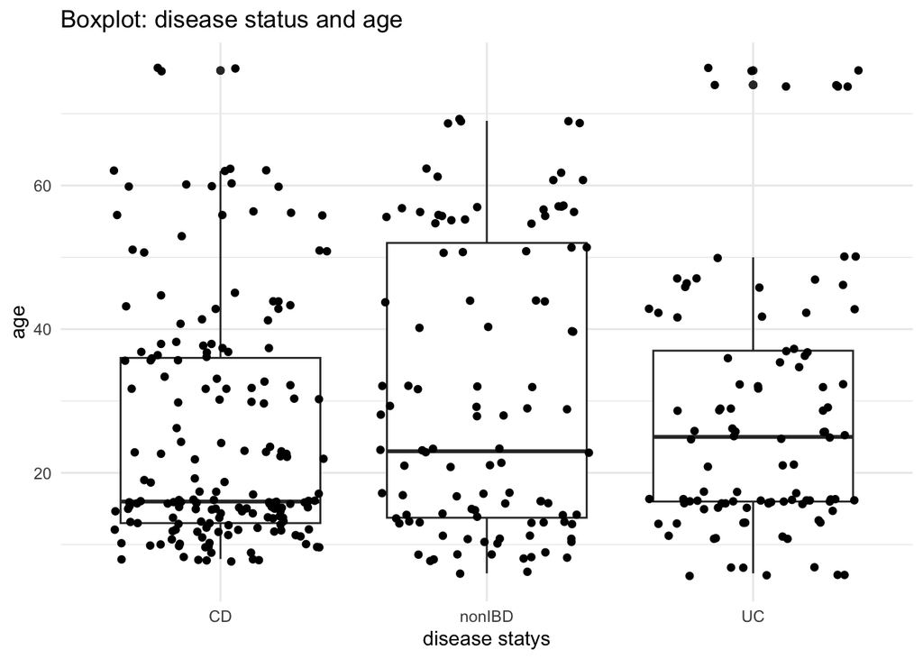

```r
ggplot(data, aes(x = Study.Group, y = consent_age)) +
  geom_boxplot() +
  geom_jitter()+
  labs(title = "Boxplot: disease status and age", x = "disease statys", y = "age") +
  theme_minimal()
```

Is there a visual correlation between the fecalcal of the patient and the disease status?

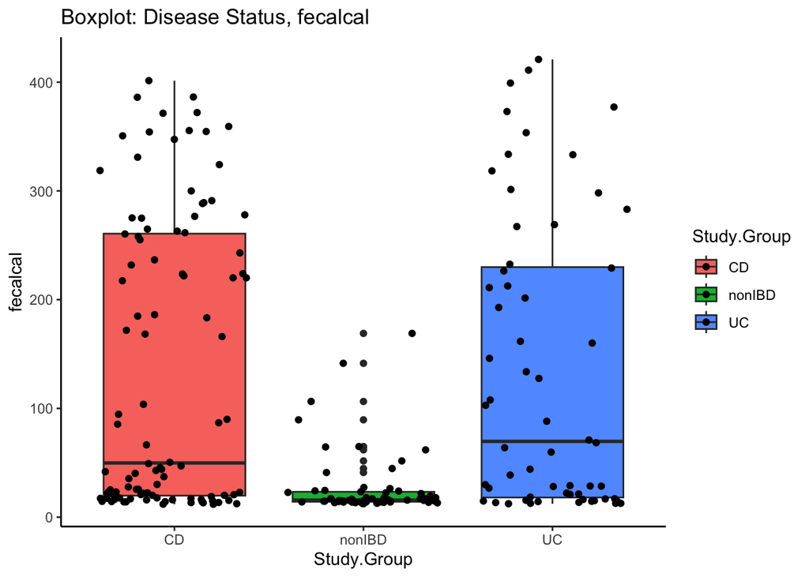

```r
ggplot(data, aes(x = Study.Group, y = fecalcal, fill = Study.Group)) +
  geom_boxplot() +
  geom_jitter() +
  theme_classic() +
  ggtitle("Boxplot: Disease Status, fecalcal")
```

Is there a visual correlation between consent age, disease status and fecalcal?

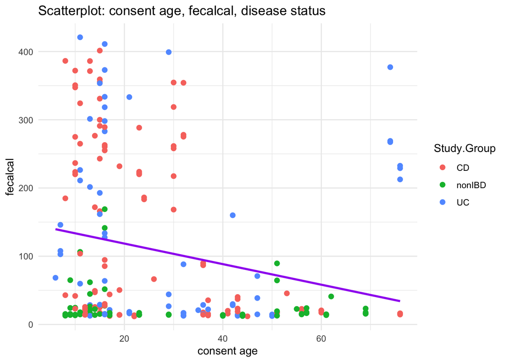

```r
ggplot(data, aes(x = consent_age, y = fecalcal, color = Study.Group)) +
  geom_point(size = 2) +
  geom_smooth(method = "lm", se = FALSE, color = "purple")+
  labs(title = "Scatterplot: consent age, fecalcal, disease status", x = "consent age", y = "fecalcal") +
  theme_minimal()
```

Upon visual inspection, there appears to be a higher fecalcal when the consent age is lower. It was decided to divide consent age in groups.

```r
data <- data %>%
  mutate(agegroup = case_when(
    consent_age <= 18 ~ "0-18",
    consent_age <= 40 ~ "19-40",
    TRUE ~ "41+"
  ))
```

Is there a more clear visual correlation between consent age, disease status and fecalcal if a boxplot instead of a scatterplot is used?

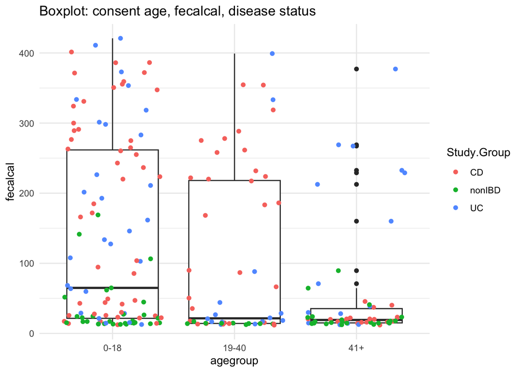

```r
ggplot(data, aes(x = agegroup, y = fecalcal)) +
  geom_boxplot() +
  geom_jitter(aes(color = Study.Group))+
  labs(title = "Boxplot: consent age, fecalcal, disease status", x = "agegroup", y = "fecalcal") +
  theme_minimal()
```

Is there a visual correlation between the smoking status of the patient, the fecalcal and the agegroup?

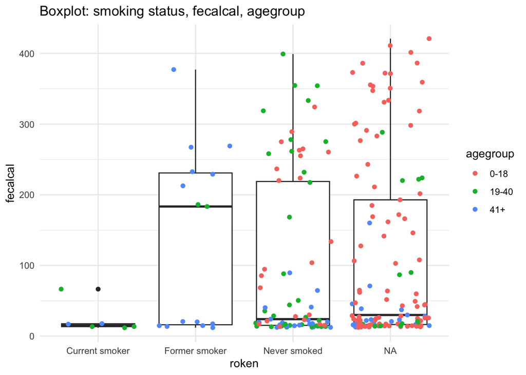

```r
ggplot(data, aes(x = `smoking status`, y = `fecalcal`)) +
  geom_boxplot() +
  geom_jitter(aes(color = agegroup))+
  labs(title = "Boxplot: smoking status, fecalcal, agegroup", x = "roken", y = "fecalcal") +
  theme_minimal()
```

Based on the big amount of NA in the smoking status, smoking will not be integrated in a test. Next, the disease status of the patient is visualy correlated with the gender and the agegroup.

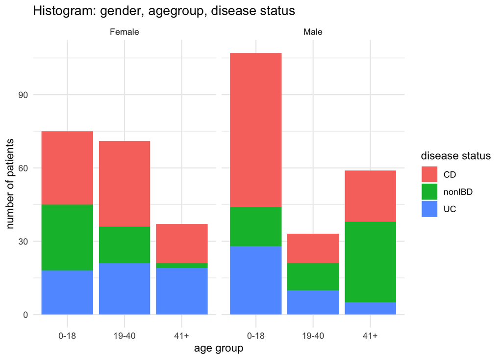

```r
ggplot(data, aes(x = agegroup, fill = Study.Group)) +
  geom_bar(position = "stack") +
  facet_wrap(~Gender) +
  labs(
    title = "Histogram: gender, agegroup, disease status",
    x = "age group",
    y = "number of patients",
    fill = "disease status"
  ) +
  theme_minimal()
```

Is there a visual correlation between the age of the patient, the race and the hospital they went to?

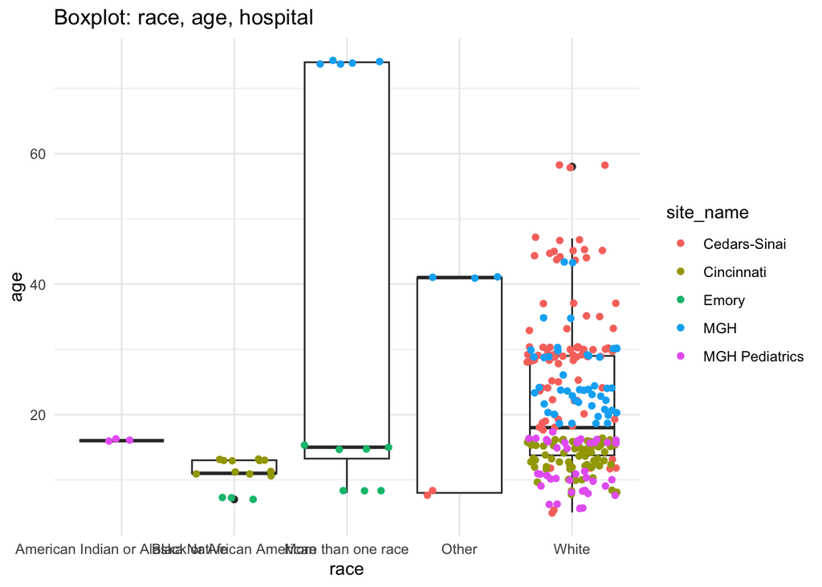

```r
ggplot(data, aes(x = race, y = `Age at diagnosis`)) +
  geom_boxplot() +
  geom_jitter(aes(color = site_name))+
  labs(title = "Boxplot: race, age, hospital", x = "race", y = "age") +
  theme_minimal()
```

1.3) CREATING THE DATAFRAME MOST_ABUNDANT

Creating a new dataframe called ‘most_abundant’ containing the samples and their most abundant bacteria.

```r
most_abundant <- data.frame(
  Sample = bact$Sample,
  Most_abundant_bact = apply(bact[, -1], 1, function(row) {
    colnames(bact)[-1][which.max(row)]
  })
)
```

Add a new column with only the phylum to the most_abundant dataframe.

```r
most_abundant$Most_abundant_phylum <- sapply(most_abundant$Most_abundant_bact, function(x) {
  parts <- strsplit(x, ";")[[1]]
  second_name <- parts[2]
  return(second_name)
})
```

How many options are there for the most abundant phylum?

```r
unique_values <- table(most_abundant$Most_abundant_phylum)
print(unique_values)
```

```
##
##      p__Bacteroidota        p__Firmicutes      p__Firmicutes_A
##                  322                    1                   40
##      p__Firmicutes_C    p__Proteobacteria p__Verrucomicrobiota
##                    4                    9                    6
```

The vast majority of most abundant bacteria belong to the phylum of Bacteroidota. The other phyla will be combined under the name ‘other phylum’.

```r
most_abundant$Most_abundant_phylum2 <- ifelse(
  grepl("p__Firmicutes|p__Proteobacteria|p__Verrucomicrobiota", most_abundant$Most_abundant_phylum),
  "other phylum",
  most_abundant$Most_abundant_phylum
)
```

Did this work?

```r
unique_values_2 <- table(most_abundant$Most_abundant_phylum2)
print(unique_values_2)
```

```
##
##    other phylum p__Bacteroidota
##              60             322
```

To be able to construct a test with this dataprame, it would be handy to have the column with the disease status of te patient added to this newly generated dataframe ‘most_abundant’.

```r
most_abundant <- merge(most_abundant, data[, c("Sample", "Study.Group")], by = "Sample", all.x = TRUE)
```

Did this work?

```r
head(most_abundant)
```

```
##     Sample
## 1 CSM5MCVN
## 2 CSM5MCWE
## 3 CSM5MCX3
## 4 CSM5MCXL
## 5 CSM5MCY8
## 6 CSM5MCZ3
##                                                                             Most_abundant_bact
## 1 d__Bacteria;p__Bacteroidota;c__Bacteroidia;o__Bacteroidales;f__Bacteroidaceae;g__Phocaeicola
## 2  d__Bacteria;p__Firmicutes_A;c__Clostridia;o__Lachnospirales;f__Lachnospiraceae;g__Roseburia
## 3 d__Bacteria;p__Bacteroidota;c__Bacteroidia;o__Bacteroidales;f__Bacteroidaceae;g__Phocaeicola
## 4 d__Bacteria;p__Bacteroidota;c__Bacteroidia;o__Bacteroidales;f__Bacteroidaceae;g__Bacteroides
## 5 d__Bacteria;p__Bacteroidota;c__Bacteroidia;o__Bacteroidales;f__Bacteroidaceae;g__Bacteroides
## 6 d__Bacteria;p__Bacteroidota;c__Bacteroidia;o__Bacteroidales;f__Bacteroidaceae;g__Phocaeicola
##   Most_abundant_phylum Most_abundant_phylum2 Study.Group
## 1      p__Bacteroidota       p__Bacteroidota          CD
## 2      p__Firmicutes_A          other phylum          CD
## 3      p__Bacteroidota       p__Bacteroidota          UC
## 4      p__Bacteroidota       p__Bacteroidota          UC
## 5      p__Bacteroidota       p__Bacteroidota          UC
## 6      p__Bacteroidota       p__Bacteroidota          CD
```

This table is ready for testing.

1.4) CREATING THE NEW DATAFRAME DIVERSITY_DF

Calculating the number of different bacteria in each sample.

```r
diversity <- rowSums(bact_filtered != 0)
print(diversity)
```

```
##   [1]  920 1543 1625 1558 1725 1018 1227 1684 1320 1362 1597  910 1545 1480 1450
##  [16] 1717 1396 1584 1712 1402 2037 2027 1390 1943 1178  974  210 1559 1351 1406
##  [31] 1593 1046 1649 1426 1606 1557 1521  639 2293 1473 1522 1310 2166 1354 1195
##  [46] 1333 1199 1522 1674 1769  799 1460 2222 1458 1028 1171 1353 1517 1286 1343
##  [61] 1847 1698 2840 1224 1249 1798 1361 1834 1625 1162 1501 1297 2209 1791 1040
##  [76] 1248 1905  572 1688  769 1486 2572 1318 1475 1680 1351 1233  840 1989 1727
##  [91] 1221 1543 2031 1230 1603  921 1180 2511 1965  950 1450 1109 1914 1290  874
## [106] 1248 1610 1704  994 1689 1857 1364 1662 1563 1183 1422 1619 1357 1630 1504
## [121] 1746 2112  494 1694 1805 1131 1188 1653 1059 2924 2248 1435 1362 1269 1884
## [136] 1434  799 1460  884 1775 1523 1701 1177 1524 1911 1274 1639 1072 1671  666
## [151] 1181 1529 1758 1607 1428 1379 1292 1871 1205 2139 1298 1085 1105  581 1451
## [166] 1595 2401 1410  946 1270 1761 1170 1883 1397 2180 1651 1456 1472 1751 1715
## [181] 1566 1243 1720 1447 1526 1979 1761 1589 1823 1163 1625 1704 1073  837 1429
## [196] 1845  973 1583 1849  149  827 1235 1291 2726  953 1262 2575 1225 1358 1392
## [211] 1435 1619 1512  282 1631 2224 1202 1236  814  564 1604 1606 2015 1687 1018
## [226] 1503 1467 1104 1153 1727 2521 1850 1171 1532 1627 1523 1503 1301 1787 1586
## [241] 1467 1074  650 1758 1253 1903 2221 1823 1606 1538 2200 1262 1131 1127 1704
## [256] 1902 2426 1628 1638 1317 1632 1465 1016  820 1275  859 1266 1841 1600 2087
## [271] 1484 2116 1272 1494 1796 1330 1709 1882  826 1329 1367 1761 1882 1604 2039
## [286] 2138 1357 1303 1473 1411 1319 2001 1805 1818 1064 1392  587 1546 1660  967
## [301] 1913  488 1070  945 1260 1666 1458 1469 1791 1598 1756 1547 2010 1565 1813
## [316] 2328 1462 1433 1530 2232 1180  979 1369  461 1288 1347 1201 1001 1723 1942
## [331] 1869 1287 1372 1808  557 1637 1278 1385 2097 1545 1205 1764  549 2336 1449
## [346]  378  318 1521 1550 1338 1191 1343 1300 1952 1448 1357 1581 1735 1501 1754
## [361] 1174 1488 1135 1432 1180 1820 1310 2097 1269 1250 1106 1431 1642 1917 1328
## [376] 1699 1644 1968 1786 1206 1517 1685
```

These data were added to the bact_filtered dataset in the column ‘diversity’

```r
bact_filtered$diversity <- diversity
```

A new dataframe ‘diversity_df’ was created, consisting of the columns ‘diversity’ and ‘Sample’.

```r
diversity_df <- bact_filtered %>%
  select(Sample, diversity)
diversity_df
```

```
## # A tibble: 382 × 2
##    Sample   diversity
##    <chr>        <dbl>
##  1 MSM5LLDS       920
##  2 ESM5MEBE      1543
##  3 MSM6J2IQ      1625
##  4 HSM5MD62      1558
##  5 HSM5MD5D      1725
##  6 ESM5MEDN      1018
##  7 CSM5MCVN      1227
##  8 MSM5LLF4      1684
##  9 HSM5MD4O      1320
## 10 ESM5MEBU      1362
## # ℹ 372 more rows
```

The column ‘Study.Group’, ‘consent_age’, ‘Weight_at_baseline’, ‘fecalcal’ from the ‘data’ dataset was merged into the new dataframe ‘diversity_df’.

```r
diversity_df <- diversity_df %>%
  inner_join(data %>% select(Sample, Study.Group, consent_age, Weight_at_baseline, fecalcal), by = "Sample")
diversity_df
```

```
## # A tibble: 382 × 6
##    Sample   diversity Study.Group consent_age Weight_at_baseline fecalcal
##    <chr>        <dbl> <fct>             <dbl>              <dbl>    <dbl>
##  1 MSM5LLDS       920 CD                   30               58      355.
##  2 ESM5MEBE      1543 CD                    8               NA       NA
##  3 MSM6J2IQ      1625 CD                   30               84      168.
##  4 HSM5MD62      1558 CD                   15               59.6    300.
##  5 HSM5MD5D      1725 nonIBD               13               95.3     NA
##  6 ESM5MEDN      1018 CD                   17               44       44.0
##  7 CSM5MCVN      1227 CD                   76               NA       16.0
##  8 MSM5LLF4      1684 CD                   22               80       13.3
##  9 HSM5MD4O      1320 CD                   15               56.3    331.
## 10 ESM5MEBU      1362 UC                    7               30.6    103.
## # ℹ 372 more rows
```

Checking if this newly generated column diversity is normally distributed. Firstly, this was checked with a QQplot.

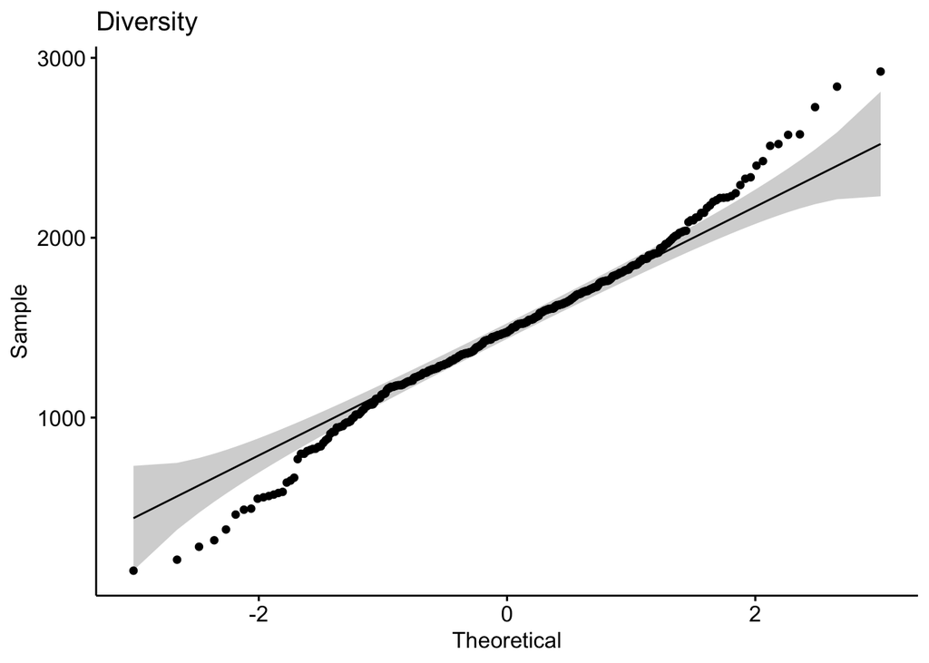

```r
library(ggpubr)
ggqqplot(diversity_df$diversity)+
  ggtitle("Diversity")
```

Normal distribution was also tested with a histogram.

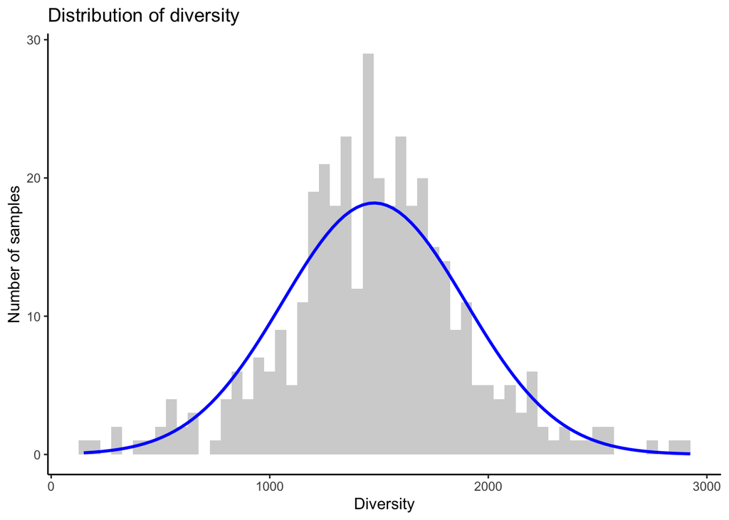

```r
bw <- 50
ggplot(bact_filtered, aes(x = diversity)) +
  geom_histogram(binwidth = bw, fill = "lightgrey") +
  stat_function(fun = function(x) {
    dnorm(x, mean = mean(diversity_df$diversity),
          sd = sd(diversity_df$diversity)) * bw * length(diversity_df$diversity)
  }, color ="blue", size = 1) +
  theme_classic() +
  labs(y = "Number of samples", x = "Diversity") +
  ggtitle("Distribution of diversity")
```

Both visualisation suggest that ‘diversity’ is normally distributed. A Shapiro-Wilk test is performed to statistically check whether this diversity is normally distributed.

```r
shapiro_result <- shapiro.test(bact_filtered$diversity)
print(shapiro_result)
```

```
##
##  Shapiro-Wilk normality test
##
## data:  bact_filtered$diversity
## W = 0.98527, p-value = 0.0006276
```

Visualisation of the diversity and the study group was done by the following code.

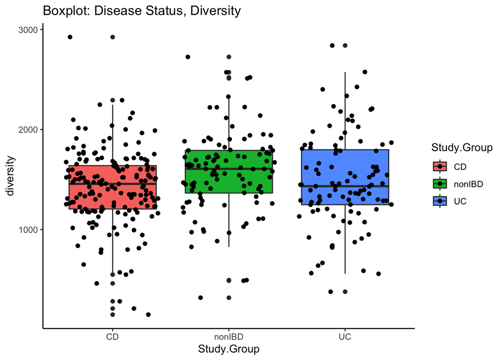

```r
diversity_df%>% ggplot(aes(x = Study.Group, y = diversity, fill = Study.Group)) +
  geom_boxplot() +
  geom_jitter() +
  theme_classic() +
  ggtitle("Boxplot: Disease Status, Diversity")
```

Chapter 2: testing a hypothesis with an univariate test.

To perform the Chi-squared test, a contingency_table needs to be constructed between the column ‘most_abundant_phylum2’ and the column ‘Study.Group’, both part of the dataframe ‘most_abundant’

```r
contingency_table <- table(most_abundant$Most_abundant_phylum2, most_abundant$Study.Group)

print(contingency_table)
```

```
##
##                    CD nonIBD  UC
##   other phylum     29     18  13
##   p__Bacteroidota 148     86  88
```

One of the conditions of the Chi-square test of independence is that the expected frequency in each cell of the contingency table should be at least 5. This was calculated by using the contingency_table generated above.

```r
row_totals <- rowSums(contingency_table)
col_totals <- colSums(contingency_table)
grand_total <- sum(contingency_table)

expected <- outer(row_totals, col_totals) / grand_total

print(expected)
```

```
##                        CD   nonIBD       UC
## other phylum     27.80105 16.33508 15.86387
## p__Bacteroidota 149.19895 87.66492 85.13613
```

To make the meaning of these values more clear, a dataframe containting the observed and expected frequencies was created.

```r
observed_df <- as.data.frame(as.table(contingency_table))
expected_df <- as.data.frame(as.table(expected))

df_observed_expected <- data.frame(
  most_abundant_phylum = observed_df$Var1,
  disease_status = observed_df$Var2,
  observed = observed_df$Freq,
  expected = expected_df$Freq
)

print(df_observed_expected)
```

```
##   most_abundant_phylum disease_status observed  expected
## 1         other phylum             CD       29  27.80105
## 2      p__Bacteroidota             CD      148 149.19895
## 3         other phylum         nonIBD       18  16.33508
## 4      p__Bacteroidota         nonIBD       86  87.66492
## 5         other phylum             UC       13  15.86387
## 6      p__Bacteroidota             UC       88  85.13613
```

There are no values smaller than 5 in the column ‘expected’, so the Chi-square test can be performed.

```r
chi_square_result <- chisq.test(contingency_table)
chi_square_result
```

```
##
##  Pearson's Chi-squared test
##
## data:  contingency_table
## X-squared = 0.876, df = 2, p-value = 0.6453
```

To visualize the chi-square test, a bar chart was constructed.

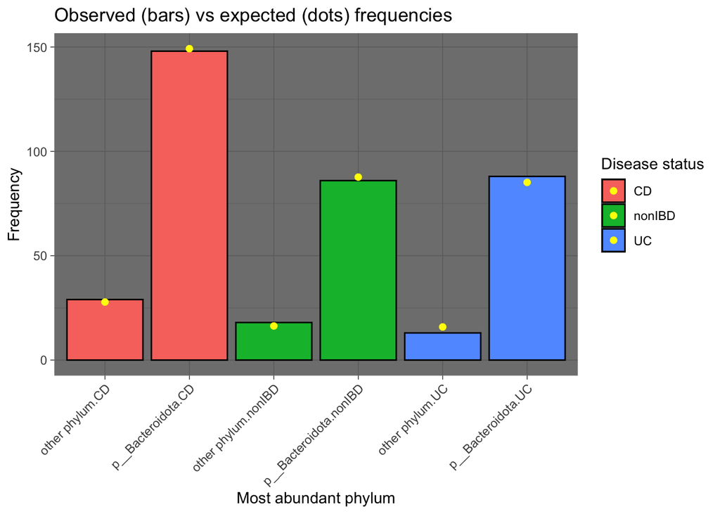

```r
library(ggplot2)
ggplot(df_observed_expected, aes(x = interaction(most_abundant_phylum, disease_status), fill = disease_status)) +
  geom_bar(aes(y = observed), stat = "identity", position = "dodge", color = "black") +
  geom_point(aes(y = expected), position = position_dodge(width = 0.5), color = "yellow", size = 1.8) +
  labs(title = "Observed (bars) vs expected (dots) frequencies",
       x = "Most abundant phylum",
       y = "Frequency",
       fill = "Disease status") +
  theme_dark() +
  theme(axis.text.x = element_text(angle = 45, hjust = 1))
```

Chapter 3: Multivariate testing

Let’s first load the tidyverse library as this will be needed for further visualisation.

```r
library(tidyverse)
```

During data exploration, a univariate Anova showed significant differences between the mean diversity across the study groups. A post-hoc Tuckey test checks which groups are significantly different.

```r
anova_diversity_group <- aov(diversity ~ Study.Group, data = diversity_df)
summary(anova_diversity_group)
```

```
##              Df   Sum Sq Mean Sq F value  Pr(>F)
## Study.Group   2  1682149  841075   4.891 0.00799 **
## Residuals   379 65170198  171953
## ---
## Signif. codes:  0 '***' 0.001 '**' 0.01 '*' 0.05 '.' 0.1 ' ' 1
```

This visualisation show this difference more clearly:

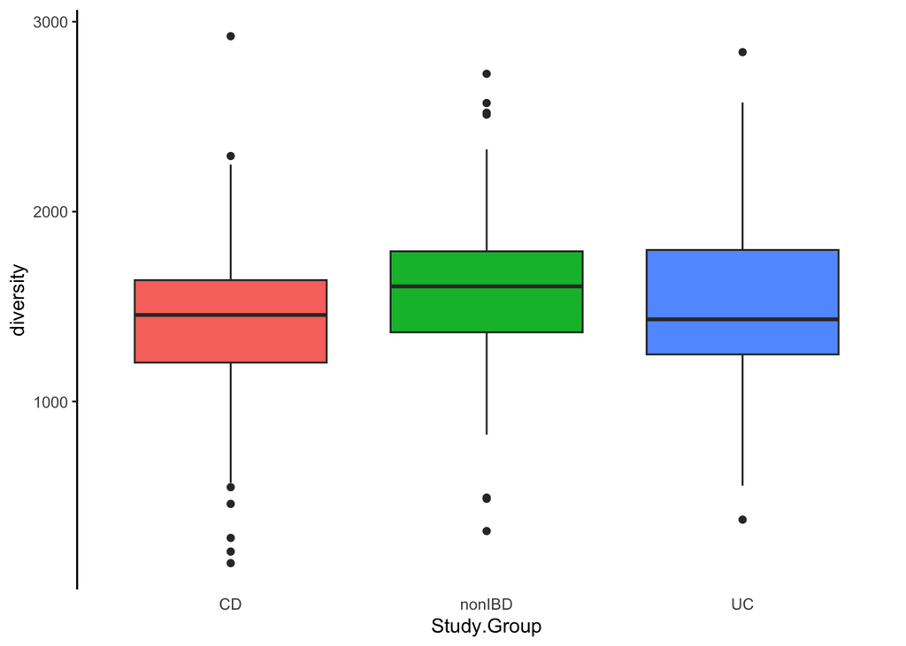

```r
anova_diversity_group %>%
  ggplot(aes(x=Study.Group, y=diversity, fill=Study.Group))+
  geom_boxplot()+
  theme_classic()+
  theme(axis.ticks.x = element_blank(), axis.line.x = element_blank(), legend.position = "none")
```

A post hoc test will show which groups differ significantly from each other.

```r
TukeyHSD(anova_diversity_group)
```

```
##   Tukey multiple comparisons of means
##     95% family-wise confidence level
##
## Fit: aov(formula = diversity ~ Study.Group, data = diversity_df)
##
## $Study.Group
##                diff        lwr       upr     p adj
## nonIBD-CD 160.08540   39.53491 280.63588 0.0054336
## UC-CD      65.94412  -55.72887 187.61711 0.4100450
## UC-nonIBD -94.14128 -230.44844  42.16588 0.2362982
```

With a p-value of 0.005, the mean diversity is statistically different in CD compaired to nonIBD.

These findings spiked interest to investigate the predictive value of diversity on study group. Besides diversity, the independant variables fecalcal, consent_age and Weight_at_baseline were included in the model.

The dependant variable (Study.Group) is nominal, categorical, and consists of three classes, and as multiple independent variables are included, a multinomial multivariate regression analysis was performed.  
In order to perform this analysis, installation of the nnet package is needed.

```r
library(nnet)
```

Next, the multinomial multivariate regression model is calculated.

```r
mlm_Study.Group <- multinom(Study.Group ~ diversity + fecalcal + consent_age + Weight_at_baseline, data = diversity_df)
summary(mlm_Study.Group)
```

```
## Call:
## multinom(formula = Study.Group ~ diversity + fecalcal + consent_age +
##     Weight_at_baseline, data = diversity_df)
##
## Coefficients:
##        (Intercept)    diversity      fecalcal consent_age Weight_at_baseline
## nonIBD   0.5308313 0.0002842826 -0.0174617463  0.01503671       -0.008958308
## UC      -0.8259994 0.0002302249  0.0007173443  0.02582673       -0.012305974
##
## Std. Errors:
##        (Intercept)    diversity    fecalcal consent_age Weight_at_baseline
## nonIBD   0.5406525 0.0003911381 0.004327075  0.01502911        0.009134711
## UC       0.5441645 0.0003571383 0.001348716  0.01337611        0.009398855
##
## Residual Deviance: 327.6086
## AIC: 347.6086
```

CD appears to be the baseline comparator in this model. Instead, let’s set nonIBD as the baseline, as it provides a more logical reference point for comparing the effects of the independant variables.

```r
levels(diversity_df$Study.Group)
```

```
## [1] "CD"     "nonIBD" "UC"
```

```r
diversity_df$Study.Group <-relevel(diversity_df$Study.Group,ref = "nonIBD")
levels(diversity_df$Study.Group)
```

```
## [1] "nonIBD" "CD"     "UC"
```

The multinomial multivariate regression model is calculated again with the adjusted baseline comparator.

```r
mlm_Study.Group <- multinom(Study.Group ~ diversity + fecalcal + consent_age + Weight_at_baseline, data = diversity_df)
summary(mlm_Study.Group)
```

```
## Call:
## multinom(formula = Study.Group ~ diversity + fecalcal + consent_age +
##     Weight_at_baseline, data = diversity_df)
##
## Coefficients:
##    (Intercept)     diversity   fecalcal consent_age Weight_at_baseline
## CD  -0.5307235 -2.843458e-04 0.01746190 -0.01503766        0.008958456
## UC  -1.3568596 -5.407121e-05 0.01817934  0.01078909       -0.003346773
##
## Std. Errors:
##    (Intercept)    diversity    fecalcal consent_age Weight_at_baseline
## CD   0.5185632 0.0003765251 0.004290942  0.01508055        0.009245241
## UC   0.4173474 0.0003715998 0.004316685  0.01599875        0.010435028
##
## Residual Deviance: 327.6086
## AIC: 347.6086
```

For interpretation of these coefficients, calculation of p-values is required. For calculattion of the p-values, the corresponding z-values are needed first.

Calculation of the z-values:

```r
coef_matrix <- mlm_Study.Group$coefficients
coef_matrix
```

[output not shown]

```r
se_matrix <- mlm_Study.Group$standard.errors
se_matrix
```

[output not shown]

```r
z_values <- coef_matrix / se_matrix
z_values
```

[output not shown]

Calculation of the p-values:

```r
p_values <- 2 * (1 - pnorm(abs(z_values)))
p_values
```

[output not shown]

For better understanding of this significant p-value: a binary logistic regression model on fecalcal for UC versus healthy and CD versus healthy. For these two regression models, two new subset dataframes were created. In the first subset dataframe UC was removed for the column study group, leaving only CD and nonIBD. This step made sure a dichotomous single dependant variable was present for both regression models.

Creation of the subset dataframes:

```r
diversity_df_subset_CD_nonIBD <- subset(diversity_df, Study.Group %in% c("CD", "nonIBD"))
diversity_df_subset_UC_nonIBD <- subset(diversity_df, Study.Group %in% c("UC", "nonIBD"))
```

Making the categories in this column binary

```r
diversity_df_subset_CD_nonIBD <- diversity_df_subset_CD_nonIBD %>%
  mutate(Study.Group = ifelse(Study.Group %in% c("CD"), 1, 0))

diversity_df_subset_UC_nonIBD <- diversity_df_subset_UC_nonIBD %>%
  mutate(Study.Group = ifelse(Study.Group %in% c("UC"), 1, 0))
```

Binomial regression model 1: the risk on Crohn Disease based on fecalcal value

```r
blm_fecalcal_1 <- glm(Study.Group ~ fecalcal, data=diversity_df_subset_CD_nonIBD, family="binomial" )
summary(blm_fecalcal_1)
```

```
##
## Call:
## glm(formula = Study.Group ~ fecalcal, family = "binomial", data = diversity_df_subset_CD_nonIBD)
##
## Coefficients:
##              Estimate Std. Error z value Pr(>|z|)
## (Intercept) -0.484033   0.231336  -2.092   0.0364 *
## fecalcal     0.016357   0.004139   3.952 7.76e-05 ***
## ---
## Signif. codes:  0 '***' 0.001 '**' 0.01 '*' 0.05 '.' 0.1 ' ' 1
##
## (Dispersion parameter for binomial family taken to be 1)
##
##     Null deviance: 213.65  on 160  degrees of freedom
## Residual deviance: 168.79  on 159  degrees of freedom
##   (120 observations deleted due to missingness)
## AIC: 172.79
##
## Number of Fisher Scoring iterations: 6
```

Visualisation of binomial regression model 1: the risk on Crohn Disease based on fecalcal value

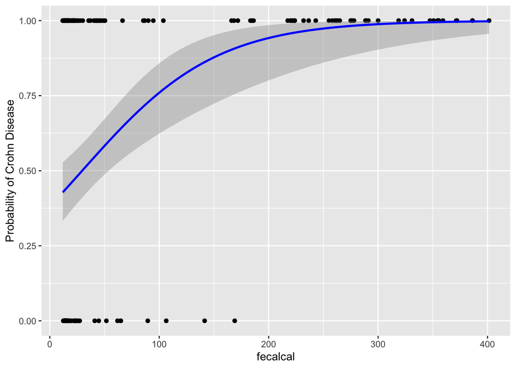

```r
plot_blm_1 <- ggplot(diversity_df_subset_CD_nonIBD, aes(x = fecalcal, y = Study.Group)) +
  geom_point() +
  geom_smooth(method = "glm", col = "blue",method.args = list(family = "binomial")) +
  labs(y = "Probability of Crohn Disease")
plot_blm_1
```

Binomial regression model 2: the risk on Ulcerative Colitis based on fecalcal value

```r
blm_fecalcal_2 <- glm(Study.Group ~ fecalcal, data=diversity_df_subset_UC_nonIBD, family="binomial" )
summary(blm_fecalcal_2)
```

```
##
## Call:
## glm(formula = Study.Group ~ fecalcal, family = "binomial", data = diversity_df_subset_UC_nonIBD)
##
## Coefficients:
##              Estimate Std. Error z value Pr(>|z|)
## (Intercept) -1.056026   0.275879  -3.828 0.000129 ***
## fecalcal     0.017989   0.004709   3.820 0.000134 ***
## ---
## Signif. codes:  0 '***' 0.001 '**' 0.01 '*' 0.05 '.' 0.1 ' ' 1
##
## (Dispersion parameter for binomial family taken to be 1)
##
##     Null deviance: 167.73  on 120  degrees of freedom
## Residual deviance: 128.98  on 119  degrees of freedom
##   (84 observations deleted due to missingness)
## AIC: 132.98
##
## Number of Fisher Scoring iterations: 6
```

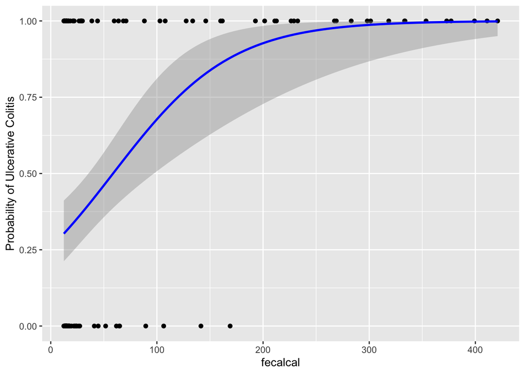

```r
plot_blm_2<- ggplot(diversity_df_subset_UC_nonIBD, aes(x = fecalcal, y = Study.Group)) +
  geom_point() +
  geom_smooth(method = "glm", col = "blue",method.args = list(family = "binomial")) + labs(y = "Probability of Ulcerative Colitis")
plot_blm_2
```